# FINAL_STAT_CODE_BASE_Surgical_Site_Infections

#### Importing Libraries

```python
import pandas as pd
import seaborn as sns
import numpy as np
import warnings
import matplotlib.pyplot as plt
```

```python
warnings.simplefilter(action='ignore', category=FutureWarning)
```

```python
file_path = r"ca_ssi_adult_odp_2022.csv"
```

```python
try:
    df = pd.read_csv(file_path, encoding='ISO-8859-1')
except Exception as e:
    read_error = e
```

```python
df.shape
```

```
(6452, 19)
```

```python
df.drop_duplicates(inplace=True)
```

```python
df.shape
```

```
(6452, 19)
```

```python
df.columns = [col.lower().replace(" ", "_") for col in df.columns]
```

```python
df.columns
```

```
Index(['year', 'state', 'county', 'hai', 'operative_procedure', 'facility_id',
       'facility_name', 'hospital_category_riskadjustment', 'facility_type',
       'procedure_count', 'infections_reported', 'infections_predicted', 'sir',
       'sir_ci_95_lower_limit', 'sir_ci_95_upper_limit', 'comparison',
       'met_2020_goal', 'sir_2015', 'notes'],
      dtype='object')
```

```python
df.info()
```

```
<class 'pandas.core.frame.DataFrame'>
RangeIndex: 6452 entries, 0 to 6451
Data columns (total 19 columns):
 #   Column                            Non-Null Count  Dtype
---  ------                            --------------  -----
 0   year                              6452 non-null   int64
 1   state                             6452 non-null   object
 2   county                            6423 non-null   object
 3   hai                               6452 non-null   object
 4   operative_procedure               6452 non-null   object
 5   facility_id                       6423 non-null   float64
 6   facility_name                     6423 non-null   object
 7   hospital_category_riskadjustment  6423 non-null   object
 8   facility_type                     6423 non-null   object
 9   procedure_count                   6452 non-null   int64
 10  infections_reported               6452 non-null   int64
 11  infections_predicted              6452 non-null   float64
 12  sir                               3433 non-null   float64
 13  sir_ci_95_lower_limit             3433 non-null   float64
 14  sir_ci_95_upper_limit             3433 non-null   float64
 15  comparison                        3433 non-null   object
 16  met_2020_goal                     3433 non-null   object
 17  sir_2015                          3034 non-null   float64
 18  notes                             1946 non-null   object
dtypes: float64(6), int64(3), object(10)
memory usage: 957.8+ KB
```

```python
numeric_columns = df.select_dtypes(include="number").columns
```

```python
for col in df.columns:
    if col not in numeric_columns:
        df[col] = df[col].str.strip()
```

## Dropping the state, year, HAI columns

```python
df.drop(columns=["hai", "state", "year", "notes"], inplace = True)
```

## Removing the unknown counties by comparing with the California State Counties

```python
california_counties = "Alameda\tAlpine\tAmador\tButte\tCalaveras\tColusa\tContra Costa\tDel Norte\tEl Dorado\tFresno\tGlenn\tHumboldt\tImperial\tInyo\tKern\tKings\tLake\tLassen\tLos Angeles\tMadera\tMarin\tMariposa\tMendocino\tMerced\tModoc\tMono\tMonterey\tNapa\tNevada\tOrange\tPlacer\tPlumas\tRiverside\tSacramento\tSan Benito\tSan Bernardino\tSan Diego\tSan Francisco\tSan Joaquin\tSan Luis Obispo\tSan Mateo\tSanta Barbara\tSanta Clara\tSanta Cruz\tShasta\tSierra\tSiskiyou\tSolano\tSonoma\tStanislaus\tSutter\tTehama\tTrinity\tTulare\tTuolumne\tVentura\tYolo\tYuba"

california_counties_list = california_counties.split("\t")
```

```python
unknown_counties = df[~df['county'].isin(california_counties_list)]
unknown_counties.index
```

```
Index([ 0,  1,  2,  3,  4,  5,  6,  7,  8,  9, 10, 11, 12, 13, 14, 15, 16, 17,
       18, 19, 20, 21, 22, 23, 24, 25, 26, 27, 28],
      dtype='int64')
```

```python
df = df.drop(df.loc[unknown_counties.index].index)
```

```python
df.shape
```

```
(6423, 15)
```

```python
df.isnull().sum()
```

```
county                                 0
operative_procedure                    0
facility_id                            0
facility_name                          0
hospital_category_riskadjustment       0
facility_type                          0
procedure_count                        0
infections_reported                    0
infections_predicted                   0
sir                                 3019
sir_ci_95_lower_limit               3019
sir_ci_95_upper_limit               3019
comparison                          3019
met_2020_goal                       3019
sir_2015                            3418
dtype: int64
```

## Operative procedures: STRING

- National Healthcare Safety Network (NHSN) -defined operative procedure category identified by California Department of Public Health (CDPH) as consistent with meeting the requirements of California Health and Safety Code section 1288.55 for hospital reporting of SSI data
- The 28 reportable operative procedure categories ar : Abdominal aortic aneurysm repair, Appendix surgery, Bile duct liver or pancreatic, Cardiac surgery, Cesarean section, Colon surgery, Coronary bypass graft with chest, Coronary bypass w/ chest & donor, Exploratory abdominal surgery, Gallbladder surgery, Gastric surgery, Heart transplant, Hip prosthesis, Hysterectomy abdominal, Hysterectomy vaginal, Kidney surgery, Kidney transplant, Knee prosthesis, Laminectomy, Liver transplant, Open reduction of fracture, Ovarian surgery, Pacemaker surgery, Rectal surgery, Small bowel surgery, Spinal fusion, Spleen surgery, Thoracic surgery

```python
allowed_operative_procedures = [
    "Abdominal aortic aneurysm repair",  "Appendix surgery","Bile duct liver or pancreatic", "Cardiac surgery", "Cesarean section",
    "Colon surgery", "Coronary bypass graft with chest", "Coronary bypass w/ chest & donor","Exploratory abdominal surgery",
    "Gallbladder surgery","Gastric surgery", "Heart transplant", "Hip prosthesis", "Hysterectomy abdominal","Hysterectomy vaginal",
    "Kidney surgery","Kidney transplant","Knee prosthesis","Laminectomy","Liver transplant","Open reduction of fracture","Ovarian surgery",
    "Pacemaker surgery","Rectal surgery","Small bowel surgery","Spinal fusion","Spleen surgery","Thoracic surgery"
]
```

### Verify the column values for the operative procedure and drop the records which are not present in the list of allowed operative procedures.

```python
allowed_operative_procedures = [procedure.lower().strip() for procedure in allowed_operative_procedures]
```

```python
 df['operative_procedure'] = df['operative_procedure'].apply(lambda x: x.lower().strip().replace(",", ""))
```

```python
df['operative_procedure'] = df['operative_procedure'].apply(lambda x: "exploratory abdominal surgery" if x == "exploratory abdominal surgery (laparotomy)" else x)
```

```python
df.drop(df[df['operative_procedure'] == "all procedures" ].index, inplace = True)
```

```python
df.shape
```

```
(6092, 15)
```

## Facility ID: NUMERIC

Facility ID is the primary key used to track facility information for all facilities stored in the Electronic Licensing Management System (ELMS) maintained by the CDPH Center of Healthcare Quality, Licensing and Certification Program.

```python
df['facility_id'] = df['facility_id'].astype(int)
```

## Facility Name: STRING

Name of each California general acute care hospital reporting SSI (excluding superficial) for 28 adult operative procedures in calendar year, 2022.

```python
df['facility_name'].value_counts()
```

```
facility_name
Providence St. Joseph Hospital                                                           49
Good Samaritan Hospital                                                                  32
Uc San Diego Health La Jolla - Jacobs Medical Center & Sulpizio Cardiovascular Center    28
Stanford Health Care                                                                     28
Cedars-Sinai Medical Center                                                              28
                                                                                         ..
Shriners Hospitals For Children Northern California                                       2
Oroville Hospital                                                                         2
West Covina Medical Center                                                                2
Modoc Medical Center                                                                      1
Ojai Valley Community Hospital                                                            1
Name: count, Length: 329, dtype: int64
```

## Hospital Category Risk Adjustment: STRING

- Acute Care Hospital
- Long-Term Acute Care Hospital
- Critical Access Hospital
- Rehabilitation Hospital

However, for SSI, only the Acute Care Hospitals have risk adjustment models that are also used for Critical Access Hospitals.

NHSN does not calculate an SSI SIR for Rehabilitation Hospitals/Units and LTAC Hospitals, and thus these facility types are not included.

```python
df['hospital_category_riskadjustment'].value_counts()
```

```
hospital_category_riskadjustment
Acute Care Hospital         5882
Critical Access Hospital     210
Name: count, dtype: int64
```

## Facility Type: TEXT

- **Major Teaching**
  - major teaching hospital is a hospital that has a teaching program for medical students and a post-graduate medical training program
- **Pediatric**
  - A pediatric hospital is a hospital with inpatients predominantly age 18 years or younger.
- **Community >250 Beds**
  - A community hospital is a CDPH designation for hospitals not classified as major teaching, long-term acute care (LTAC), critical access, pediatric, or rehabilitation.
  - Community hospitals are further categorized by the number of active beds as reported by the hospital in the NHSN Annual Survey.
- **Community 125-250 Beds**
  - A community hospital is a CDPH designation for hospitals not classified as major teaching, long-term acute care (LTAC), critical access, pediatric, or rehabilitation.
  - Community hospitals are further categorized by the number of active beds as reported by the hospital in the NHSN Annual Survey.
- **Community <125 Beds**
  - A community hospital is a CDPH designation for hospitals not classified as major teaching, long-term acute care (LTAC), critical access, pediatric, or rehabilitation.
  - Community hospitals are further categorized by the number of active beds as reported by the hospital in the NHSN Annual Survey.
- **Long-Term Acute Care**
  - A LTAC hospital is defined by the Centers for Medicare & Medicaid Services (CMS) as a licensed general acute care hospital providing care for patients with medically complex conditions requiring an average length of stay greater than 25 days.
- **Critical Access**
  - A critical access hospital is designated by CMS as a hospital with 25 or fewer acute care inpatient beds, located more than 35 miles from another hospital (with some exceptions), with an average length of stay of four days or less.
- **Rehabilitation Unit**
  - A rehabilitation unit is an inpatient ward within a general acute care hospital providing evaluation and restoration of function for patients who have lost function due to:
    - Acute or chronic pain,
    - Musculoskeletal problems,
    - Stroke, or catastrophic events,
    - Resulting in complete or partial paralysis.
  - A rehabilitation unit typically has its own unique CMS certification number (CCN) and reports separately from the rest of the hospital.
- **Rehabilitation Hospital:**
  - An acute care facility exclusively providing evaluation and restoration of function for patients who have lost function due to
    - Acute or chronic pain,
    - Musculoskeletal problems,
    - Stroke, or catastrophic events,
    - Resulting in complete or partial paralysis.

NHSN does not calculate an SSI SIR for rehabilitation hospitals/units and LTAC hospitals, and thus these facility types are not included.

```python
df['facility_type'].value_counts()
```

```
facility_type
Major Teaching             2423
Community, 125-250 Beds    1267
Community, <125 Beds       1176
Community, >250 Beds        910
Critical Access             210
Pediatric                   106
Name: count, dtype: int64
```

## Procedure Count: NUMERIC

Number of procedures performed from January 1, 2022, through December 31, 2022 and reported by a hospital via NHSN

```python
df['procedure_count'].value_counts()
```

```
procedure_count
1       338
2       248
3       186
5       148
4       144
       ...
945       1
641       1
400       1
397       1
1736      1
Name: count, Length: 626, dtype: int64
```

## Infections Reported: NUMERIC

- The number of SSI reported by a hospital to the NHSN for procedures performed from January 1, 2022, through December 31, 2022.
- Counts include only deep incisional and organ/space infections that are identified during hospital Admission or Readmission to the same hospital following inpatient surgeries.

```python
df['infections_reported'].value_counts().head()
```

```
infections_reported
0    4503
1     829
2     316
3     178
4      98
Name: count, dtype: int64
```

## Infections_Predicted: NUMERIC

- The predicted number of SSI calculated using SSI probabilities estimated from multivariate logistic regression model constructed from NHSN data during a baseline year 2015, which represents a reference population’s SSI experience.

```python
df['infections_predicted'].value_counts().head()
```

```
infections_predicted
0.01    428
0.02    287
0.03    255
0.00    222
0.04    210
Name: count, dtype: int64
```

## The Standardized Infection Ratio (SIR): DECIMAL

- The Standardized Infection Ratio (SIR) is a summary measure used to track Surgical Site Infections (SSIs) over time.
- It is calculated by dividing the `number of observed infections` by the `number of predicted infections`.
- The SIRs in this table were calculated using only complex SSIs identified during:
  - Hospital Admission, or
  - Readmission to the same hospital following in-patient surgeries.
- The SIR adjusts for patient-level and hospital-level risk factors specific to each procedure type.
- `NHSN (National Healthcare Safety Network) calculates an SSI SIR when at least one infection` is`predicted`.
- The California Department of Public Health (CDPH) calculates an SIR if the predicted number of SSIs was <1 and >=0.2.
- The SIR and its comparison are not as precise as SIRs based on a larger number of predicted infections but provide more hospitals with a published interpretation of their data.

**NOTE:** See [NHSN's Guide to the SIR](https://www.cdc.gov/nhsn/2015rebaseline/index.html) at the NHSN website for more information.

```python
df = df[(df['infections_predicted'] >=0.2) & ( df['infections_predicted'] < 1)]
```

```python
df['sir'] =  df['infections_reported'] / df['infections_predicted']
```

```python
df.shape
```

```
(1931, 15)
```

## The 2015 Standardized Infection Ratio (SIR): NUMERIC

- The 2015 Standardized Infection Ratio (SIR) is a summary measure used to track Healthcare-Associated Infections (HAIs) over time.
- The SIR compares the number of reported Surgical Site Infections (SSI) to the number of predicted SSIs based on national baseline data.
- The SIR adjusts for factors that may impact the risk of acquiring an SSI.
- Calculated SIR if the number of predicted infections were >=0.2 and <1
- Hospitals with a `predicted number of SSIs equal to or less than 0.2` will `not have an SIR` calculated by NHSN (National Healthcare Safety Network) or CDPH (California Department of Public Health).

```python
 df = df[df['infections_predicted'] >0.2]
```

```python
df.shape
```

```
(1863, 15)
```

## SIR_CI_95_Lower_Limit: NUMERIC

- The lower limit of the SIR 95% confidence interval is computed using the exact Poisson distribution.
- The confidence interval quantifies the precision of the calculated SIR that is associated with random variation.

```python
df['sir_ci_95_lower_limit'].isnull().any()
```

```
False
```

## SIR_CI_95_Upper_Limit: NUMERIC

- The upper limit of the SIR 95% confidence interval is calculated using the exact Poisson distribution.
- The confidence interval quantifies the precision of the calculated SIR that is associated with random variation.

```python
df['sir_ci_95_upper_limit'].value_counts()
```

```
sir_ci_95_upper_limit
17.65    11
17.74    10
13.46    10
15.31     9
15.57     8
         ..
8.13      1
26.79     1
12.87     1
12.78     1
8.99      1
Name: count, Length: 824, dtype: int64
```

## Comparison: TEXT

- This field shows if the 95% confidence interval indicates the SSI incidence is significantly:
  - Better,
  - Worse, or
  - The same as predicted.
- If the 95% confidence interval for the SIR includes 1, the number of reported cases is not statistically significantly different from that predicted.

```python
df['comparison'].value_counts()
```

```
comparison
Same     1838
Worse      25
Name: count, dtype: int64
```

## Met_2020_Goal: TEXT

- "Yes" indicates the hospital met the 2020 national Healthcare-Associated Infections (HAI) reduction goal, as recommended by the CDPH HAI Advisory Committee, in the calendar year of 2022.
- Starting from 2015, hospitals should have achieved a 30% reduction in Surgical Site Infection (SSI) incidence (SIR < 0.70) to meet the goal.

```python
df['met_2020_goal'].value_counts()
```

```
met_2020_goal
Yes    1275
No      588
Name: count, dtype: int64
```

```python
df['sir_2015'].mean()
```

```
0.9966523911491791
```

## SIR_2015: NUMERIC

- The 2015 Standardized Infection Ratio (SIR) is a summary measure used to track Healthcare-Associated Infections (HAIs) over time.
- The SIR compares the number of reported Surgical Site Infections (SSI) to the number of predicted SSIs based on national baseline data.
- The SIR adjusts for factors that may impact the risk of acquiring an SSI.
- Hospitals with a predicted number of SSIs equal to or less than 0.2 will not have an SIR calculated by NHSN (National Healthcare Safety Network) or CDPH (California Department of Public Health).

```python
median_sir_2015 = df['sir_2015'].mean()
df['sir_2015'].fillna(median_sir_2015, inplace=True)
```

```python
df.isnull().sum() # CHECKING FOR THE NULL VALUES AGAIN AFTER CLEANING
```

```
county                              0
operative_procedure                 0
facility_id                         0
facility_name                       0
hospital_category_riskadjustment    0
facility_type                       0
procedure_count                     0
infections_reported                 0
infections_predicted                0
sir                                 0
sir_ci_95_lower_limit               0
sir_ci_95_upper_limit               0
comparison                          0
met_2020_goal                       0
sir_2015                            0
dtype: int64
```

```python
df.info()
```

```
<class 'pandas.core.frame.DataFrame'>
Index: 1863 entries, 32 to 6432
Data columns (total 15 columns):
 #   Column                            Non-Null Count  Dtype
---  ------                            --------------  -----
 0   county                            1863 non-null   object
 1   operative_procedure               1863 non-null   object
 2   facility_id                       1863 non-null   int64
 3   facility_name                     1863 non-null   object
 4   hospital_category_riskadjustment  1863 non-null   object
 5   facility_type                     1863 non-null   object
 6   procedure_count                   1863 non-null   int64
 7   infections_reported               1863 non-null   int64
 8   infections_predicted              1863 non-null   float64
 9   sir                               1863 non-null   float64
 10  sir_ci_95_lower_limit             1863 non-null   float64
 11  sir_ci_95_upper_limit             1863 non-null   float64
 12  comparison                        1863 non-null   object
 13  met_2020_goal                     1863 non-null   object
 14  sir_2015                          1863 non-null   float64
dtypes: float64(5), int64(3), object(7)
memory usage: 232.9+ KB
```

```python
numeric_columns = df.select_dtypes(include=['float64', 'int64', 'int32']).columns
numeric_columns
```

```
Index(['facility_id', 'procedure_count', 'infections_reported',
       'infections_predicted', 'sir', 'sir_ci_95_lower_limit',
       'sir_ci_95_upper_limit', 'sir_2015'],
      dtype='object')
```

## Converting met_2020_goal to BOOLEAN type

- Yes implies 1
- No implies 0

```python
df['met_2020_goal'] = df['met_2020_goal'].apply(lambda x: 1 if x == "Yes" else 0)
```

## Checking for the data distribution

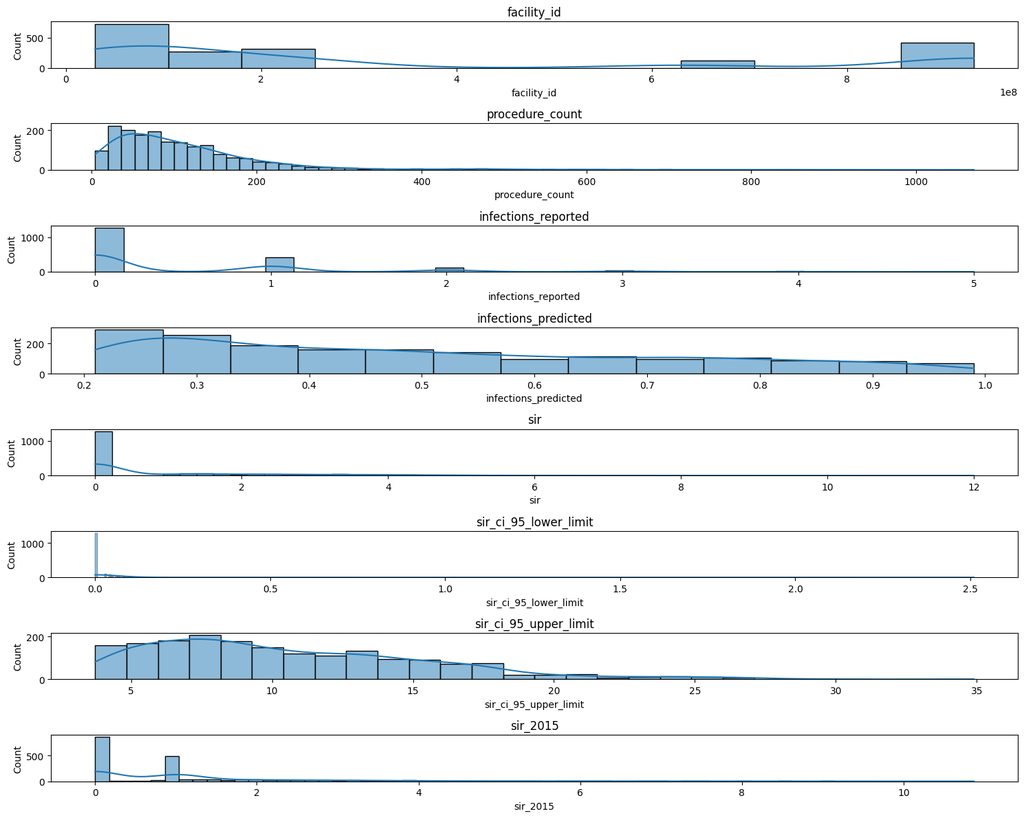

```python
plt.figure(figsize=(15, 12))
for i, col in enumerate(numeric_columns):
    plt.subplot(len(numeric_columns), 1, i+1)
    sns.histplot(df[col], kde=True)
    plt.title(col)

plt.tight_layout()
plt.show()
```

```python
statistical_summary = df[numeric_columns].describe().T
statistical_summary['skew'] = df[numeric_columns].skew()
statistical_summary['kurtosis'] = df[numeric_columns].kurtosis()

statistical_summary
```

|  | count | mean | std | min | 25% | 50% | 75% | max | skew | kurtosis |
| --- | --- | --- | --- | --- | --- | --- | --- | --- | --- | --- |
| facility_id | 1863.0 | 3.308384e+08 | 3.535751e+08 | 30000037.00 | 6.000007e+07 | 1.400002e+08 | 6.300134e+08 | 9.300015e+08 | 0.922819 | -0.925057 |
| procedure_count | 1863.0 | 1.137257e+02 | 1.054002e+02 | 4.00 | 4.700000e+01 | 8.700000e+01 | 1.450000e+02 | 1.070000e+03 | 3.156452 | 15.934083 |
| infections_reported | 1863.0 | 4.428341e-01 | 7.656922e-01 | 0.00 | 0.000000e+00 | 0.000000e+00 | 1.000000e+00 | 5.000000e+00 | 2.025128 | 4.628284 |
| infections_predicted | 1863.0 | 5.013634e-01 | 2.229082e-01 | 0.21 | 3.000000e-01 | 4.600000e-01 | 6.800000e-01 | 9.900000e-01 | 0.495392 | -0.943313 |
| sir | 1863.0 | 8.900524e-01 | 1.596450e+00 | 0.00 | 0.000000e+00 | 0.000000e+00 | 1.428571e+00 | 1.200000e+01 | 2.183179 | 5.817470 |
| sir_ci_95_lower_limit | 1863.0 | 7.434246e-02 | 2.379885e-01 | 0.00 | 0.000000e+00 | 0.000000e+00 | 4.000000e-02 | 2.510000e+00 | 5.410013 | 35.765501 |
| sir_ci_95_upper_limit | 1863.0 | 1.066422e+01 | 5.041929e+00 | 3.72 | 6.815000e+00 | 9.600000e+00 | 1.370000e+01 | 3.490000e+01 | 1.030378 | 1.193222 |
| sir_2015 | 1863.0 | 9.966524e-01 | 1.420913e+00 | 0.00 | 0.000000e+00 | 9.966524e-01 | 1.075000e+00 | 1.087000e+01 | 2.432675 | 7.973382 |

- Skewness: A measure of the asymmetry of the probability distribution. A value closer to zero indicates a more symmetrical distribution. Positive skew indicates a tail on the right side, while negative skew indicates a tail on the left.
- Kurtosis: A measure of whether the data is heavy-tailed or light-tailed compared to a normal distribution. Higher kurtosis means more of the variance is due to infrequent extreme deviations.

| Metric | Skewness | Kurtosis |
| --- | --- | --- |
| Facility ID | Moderately skewed | Lighter tails than a normal distribution |
| Procedure Count | Highly skewed to the right | Heavy-tailed |
| Infections Reported | Highly skewed to the right | Moderately heavy-tailed |
| Infections Predicted | Slightly skewed to the right | Lighter tails than a normal distribution |
| SIR | Highly skewed to the right | Moderately heavy-tailed |
| SIR CI 95% Lower Limit | Highly skewed to the right | Very heavy-tailed |
| SIR CI 95% Upper Limit | Moderately skewed to the right | Slightly heavy-tailed |
| SIR 2015 | Highly skewed to the right | Heavy-tailed |

```python
df.to_csv("sir_Dec_15.csv", index = False)
```

## Data Transformation

- square root normalizations have been applied on `procedure_count` and `infection_reported`
- Log normalizations have been applied on `infections_predicted`, `sir`, `sir_ci_95_low` and `sir_ci_95_high`

```python
import numpy as np

transformed_data = df.copy()

transformed_data['procedure_count_sqrt'] = np.sqrt(transformed_data['procedure_count'])
transformed_data['infections_reported_sqrt'] = np.sqrt(transformed_data['infections_reported'])

transformed_data['infections_predicted_log'] = np.log1p(transformed_data['infections_predicted'])
transformed_data['sir_log'] = np.log1p(transformed_data['sir'])
transformed_data['sir_ci_95_lower_limit_log'] = np.log1p(transformed_data['sir_ci_95_lower_limit'])
transformed_data['sir_ci_95_upper_limit_log'] = np.log1p(transformed_data['sir_ci_95_upper_limit'])


transformed_data[['procedure_count_sqrt', 'infections_reported_sqrt',
                  'infections_predicted_log', 'sir_log',
                  'sir_ci_95_lower_limit_log', 'sir_ci_95_upper_limit_log']].describe()
```

|  | procedure_count_sqrt | infections_reported_sqrt | infections_predicted_log | sir_log | sir_ci_95_lower_limit_log | sir_ci_95_upper_limit_log |
| --- | --- | --- | --- | --- | --- | --- |
| count | 1863.000000 | 1863.000000 | 1863.000000 | 1863.000000 | 1863.000000 | 1863.000000 |
| mean | 9.838893 | 0.364646 | 0.395672 | 0.399221 | 0.056659 | 2.368381 |
| std | 4.114727 | 0.556807 | 0.145352 | 0.625085 | 0.154925 | 0.419349 |
| min | 2.000000 | 0.000000 | 0.190620 | 0.000000 | 0.000000 | 1.551809 |
| 25% | 6.855655 | 0.000000 | 0.262364 | 0.000000 | 0.000000 | 2.056045 |
| 50% | 9.327379 | 0.000000 | 0.378436 | 0.000000 | 0.000000 | 2.360854 |
| 75% | 12.041595 | 1.000000 | 0.518794 | 0.887303 | 0.039221 | 2.687847 |
| max | 32.710854 | 2.236068 | 0.688135 | 2.564949 | 1.255616 | 3.580737 |

## Verifying the data distributions on the transformed variables

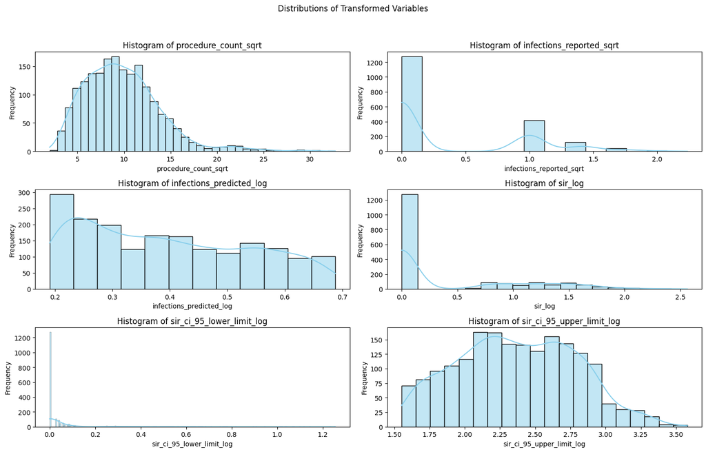

```python
fig, axes = plt.subplots(nrows=3, ncols=2, figsize=(15, 10))
fig.suptitle('Distributions of Transformed Variables')

transformed_columns = ['procedure_count_sqrt', 'infections_reported_sqrt',
                       'infections_predicted_log', 'sir_log',
                       'sir_ci_95_lower_limit_log', 'sir_ci_95_upper_limit_log']

for i, col in enumerate(transformed_columns):
    sns.histplot(transformed_data[col], kde=True, ax=axes[i//2, i%2], color='skyblue')
    axes[i//2, i%2].set_title(f'Histogram of {col}')
    axes[i//2, i%2].set_ylabel('Frequency')

plt.tight_layout(rect=[0, 0.03, 1, 0.95])
plt.show()
```

# Analyzing the data using visualizations

```python
county_data = transformed_data.groupby('county')[['infections_reported', 'infections_predicted']].sum()
top_counties_reported = county_data.sort_values(by='infections_reported', ascending=False)
```

```python
temp = pd.DataFrame(top_counties_reported)
```

```python
temp.reset_index(inplace=True)
```

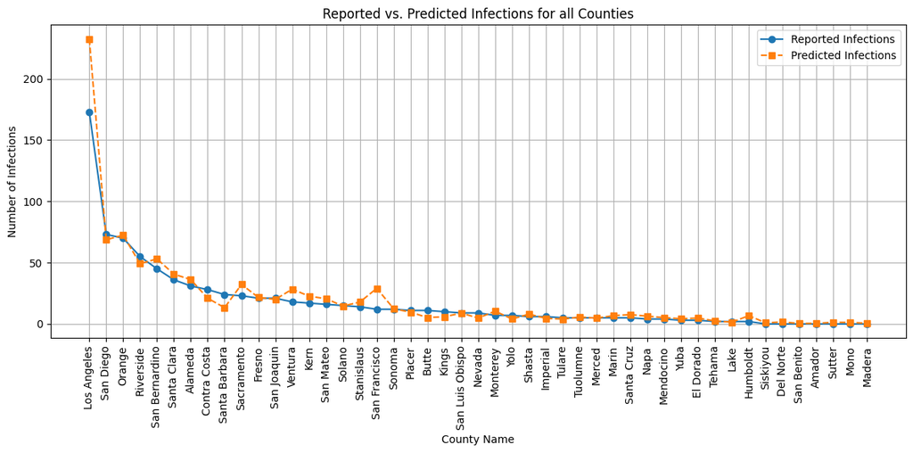

```python
plt.figure(figsize=(12, 6))
counties = temp['county']
plt.plot(counties, temp['infections_reported'], label='Reported Infections', linestyle='-', marker='o')
plt.plot(counties, temp['infections_predicted'], label='Predicted Infections', linestyle='--', marker='s')

plt.title('Reported vs. Predicted Infections for all Counties')
plt.xlabel('County Name')
plt.ylabel('Number of Infections')
plt.legend()
plt.grid(True)

plt.xticks(rotation=90)

plt.tight_layout()
plt.show()
```

- markers with `blue dot` are infections reported.
- Markers with `orange dot` are infections predicted.
- infections reported should be less than infections predicted to meet the 2020 Goals.

## Visualizing SIR for Different operative procedures

```python
grouped_data = transformed_data.groupby('operative_procedure')['sir'].mean().sort_values(ascending=False)
test = pd.DataFrame(grouped_data)
```

```python
test = pd.DataFrame(grouped_data[(grouped_data < 1) & (grouped_data > 0.2) ])
```

```python
test = test.reset_index()
```

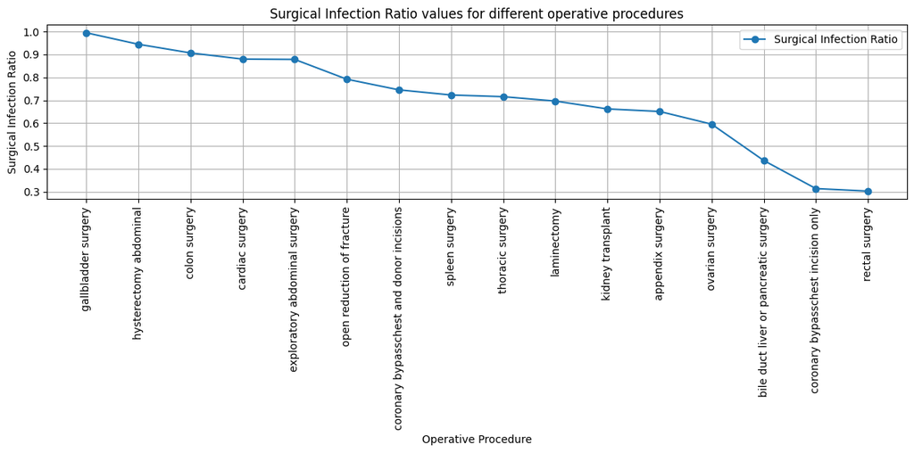

```python
plt.figure(figsize=(12, 6))
counties = test['operative_procedure']
plt.plot(counties, test['sir'], label='Surgical Infection Ratio', linestyle='-', marker='o')
plt.title('Surgical Infection Ratio values for different operative procedures')
plt.xlabel('Operative Procedure')
plt.ylabel('Surgical Infection Ratio')
plt.legend()
plt.grid(True)

plt.xticks(rotation=90)

plt.tight_layout()
plt.show()
```

- SIR should come under the range of 0.3 to less than 1.0

## Correlation Analysis for the numerical columns

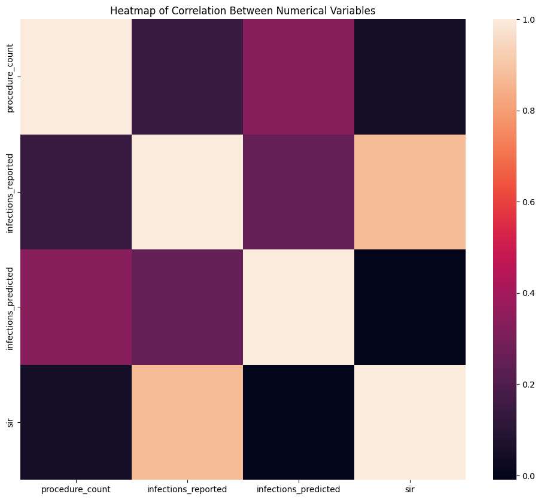

```python
subset_data = df[['procedure_count', 'infections_reported', 'infections_predicted', 'sir']]


correlation_matrix = subset_data.corr()
plt.figure(figsize=(12, 10))
heatmap = sns.heatmap(correlation_matrix)
heatmap.set_title('Heatmap of Correlation Between Numerical Variables')
plt.show()
```

## Analyzing infections reported vs infections predicted among the different facilities

```python
facility_name_value_counts = df['facility_name'].value_counts()
```

```python
top_facility_names = facility_name_value_counts[facility_name_value_counts > 10]
```

```python
top_facility_names_df = pd.DataFrame(top_facility_names).reset_index()
```

```python
facility_infections = df.groupby('facility_name').agg({
    'infections_reported': 'sum',
    'infections_predicted': 'sum'
}).reset_index()
```

```python
sorted_facility_infections = facility_infections.sort_values(
    by=['infections_reported', 'infections_predicted'], ascending=False
)
```

```python
top_facilities = sorted_facility_infections.head(10)
```

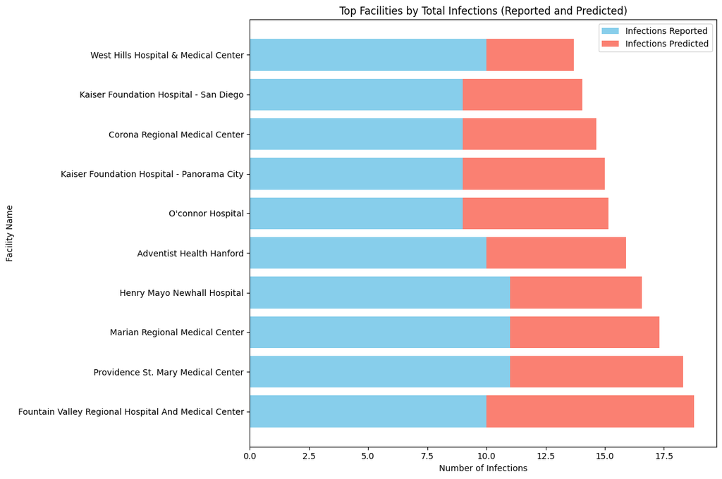

```python
top_facilities['total_infections'] = top_facilities['infections_reported'] + top_facilities['infections_predicted']
top_facilities_sorted = top_facilities.sort_values(by='total_infections', ascending=False)

plt.figure(figsize=(12, 8))

plt.barh(top_facilities_sorted['facility_name'], top_facilities_sorted['infections_reported'], color='skyblue', label='Infections Reported')
plt.barh(top_facilities_sorted['facility_name'], top_facilities_sorted['infections_predicted'], left=top_facilities_sorted['infections_reported'], color='salmon', label='Infections Predicted')

# Adding titles and labels
plt.title('Top Facilities by Total Infections (Reported and Predicted)')
plt.xlabel('Number of Infections')
plt.ylabel('Facility Name')
plt.legend()

plt.tight_layout()
plt.show()
```

## Visualizing the summary of the data using violin plot

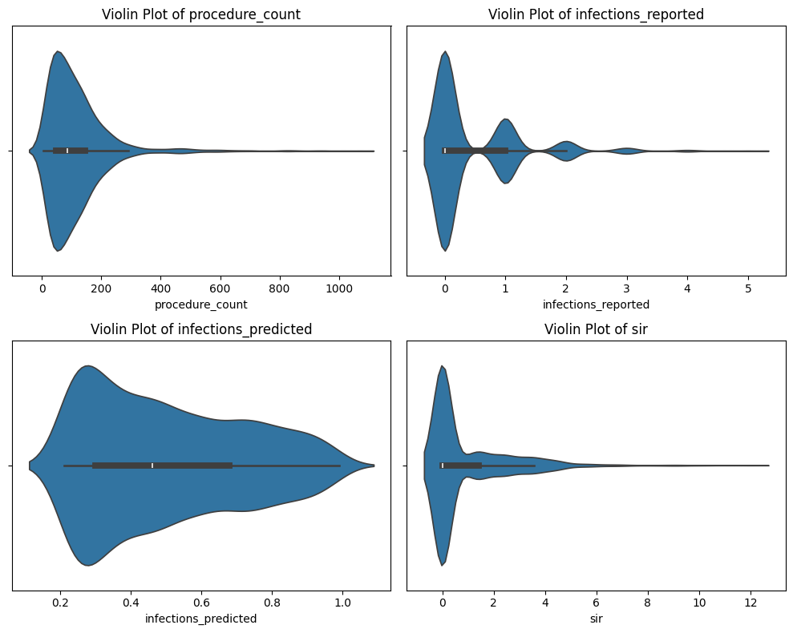

```python
plt.figure(figsize=(10, 8))

num_columns = ['procedure_count', 'infections_reported', 'infections_predicted', 'sir']

for i, col in enumerate(num_columns):
    plt.subplot(2, 2, i+1)
    sns.violinplot(x=col, data=df)
    plt.title(f'Violin Plot of {col}')

plt.tight_layout()
plt.show()
```

## Analyzing infections reported vs infections predicted among the different facility types

```python
facility_types = transformed_data.groupby('facility_type')[['infections_reported', 'infections_predicted']].sum()
top_facility_types_reported = facility_types.sort_values(by=['infections_reported', 'infections_predicted'], ascending=False)
```

```python
temp = pd.DataFrame(top_facility_types_reported).reset_index()
```

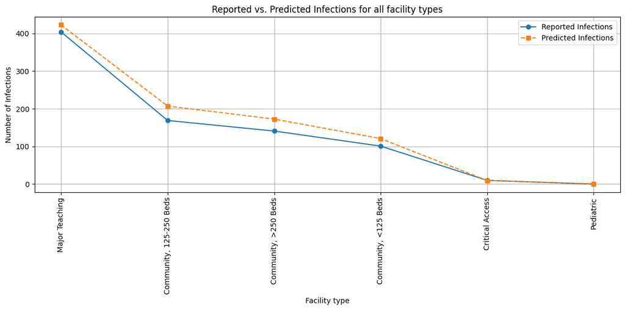

```python
plt.figure(figsize=(12, 6))
counties = temp['facility_type']
plt.plot(counties, temp['infections_reported'], label='Reported Infections', linestyle='-', marker='o')
plt.plot(counties, temp['infections_predicted'], label='Predicted Infections', linestyle='--', marker='s')

plt.title('Reported vs. Predicted Infections for all facility types')
plt.xlabel('Facility type')
plt.ylabel('Number of Infections')
plt.legend()
plt.grid(True)

plt.xticks(rotation=90)

plt.tight_layout()
plt.show()
```

## Visulazing the proportion of infection reported based on facility type

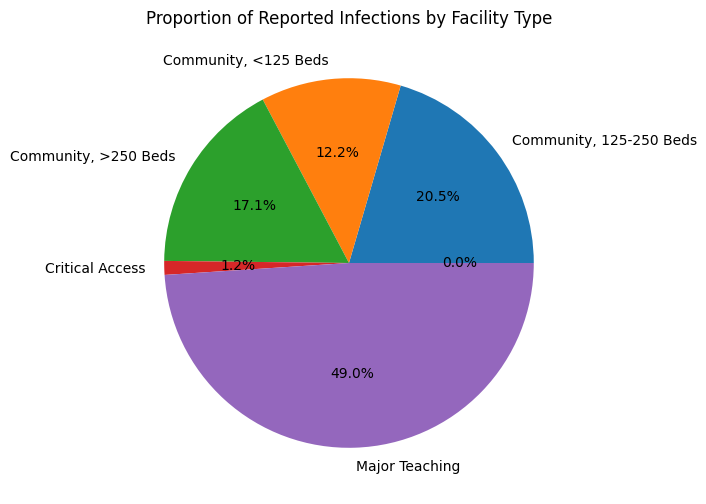

```python
facility_type_reported = df.groupby('facility_type')['infections_reported'].sum()
plt.figure(figsize=(10, 6))
facility_type_reported.plot(kind='pie', autopct='%1.1f%%')
plt.title('Proportion of Reported Infections by Facility Type')
plt.ylabel('')
plt.show()
```

```python
temp = pd.DataFrame(top_counties_reported)
```

```python
temp.reset_index(inplace=True)
```

```python
!pip install geopandas
```

[output not shown]

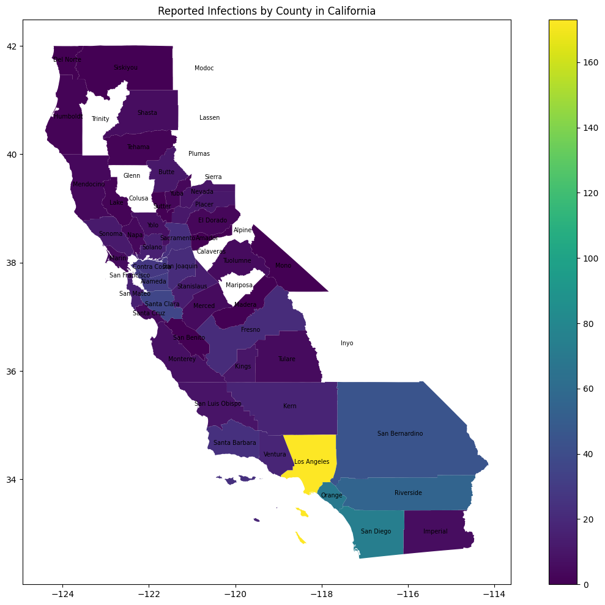

```python
import geopandas as gpd
import matplotlib.pyplot as plt

# Load your GeoDataFrame containing the California counties' geometries
gdf = gpd.read_file('California_County_Boundaries.geojson')

# Merge your SIR data with the GeoDataFrame
# Replace 'CountyName' with the actual name of the column that contains the county names in your GeoDataFrame
merged_gdf = gdf.merge(temp, how="left", left_on="CountyName", right_on="county")

# Plot the choropleth map
fig, ax = plt.subplots(1, 1, figsize=(16, 12))  # Increased figure size
merged_gdf.plot(column='infections_reported', ax=ax, legend=True)

# Annotate the county names with smaller font size
for idx, row in merged_gdf.iterrows():
    plt.annotate(text=row['CountyName'],
                 xy=(row['geometry'].centroid.x, row['geometry'].centroid.y),
                 horizontalalignment='center',
                 verticalalignment='center',
                 fontsize='x-small',  # Decreased font size
                 color='black')  # Optional: change text color if needed for visibility

plt.title('Reported Infections by County in California')
plt.show()
```

```python
df.isnull().sum()
```

```
county                              0
operative_procedure                 0
facility_id                         0
facility_name                       0
hospital_category_riskadjustment    0
facility_type                       0
procedure_count                     0
infections_reported                 0
infections_predicted                0
sir                                 0
sir_ci_95_lower_limit               0
sir_ci_95_upper_limit               0
comparison                          0
met_2020_goal                       0
sir_2015                            0
dtype: int64
```

```python
df.to_csv("cleaned_SSI_Data_2022.csv", index=False)
```

```python
df['facility_type'].value_counts()
```

```
facility_type
Major Teaching             791
Community, 125-250 Beds    448
Community, >250 Beds       316
Community, <125 Beds       280
Critical Access             25
Pediatric                    3
Name: count, dtype: int64
```

### Validating the Central Limit Theorem (CLT) with the SIR for Gastric Surgeries

Statistical Concept: Central Limit Theorem (CLT) Method: Analysis of sample means distributions for different sample sizes

**Analysis:**

The standard deviation of the sample means decreases as the sample size increases. This is consistent with the Central Limit Theorem, which states that as the sample size increases, the sampling distribution of the mean will become increasingly normal, regardless of the population's distribution.

```python
gastric_surgery_sir = df[df['operative_procedure'] == 'gastric surgery']['sir'].dropna()

sample_sizes = [10, 30, 50, 100]
sample_means = {n: [np.mean(np.random.choice(gastric_surgery_sir, n, replace=False)) for _ in range(1000)] for n in sample_sizes}

sample_means_distributions = {n: np.std(mean_list) for n, mean_list in sample_means.items()}

sample_means_distributions
```

```
{10: 0.6319537140920765,
 30: 0.3290946506436524,
 50: 0.21233042143718844,
 100: 0.07110537132931088}
```

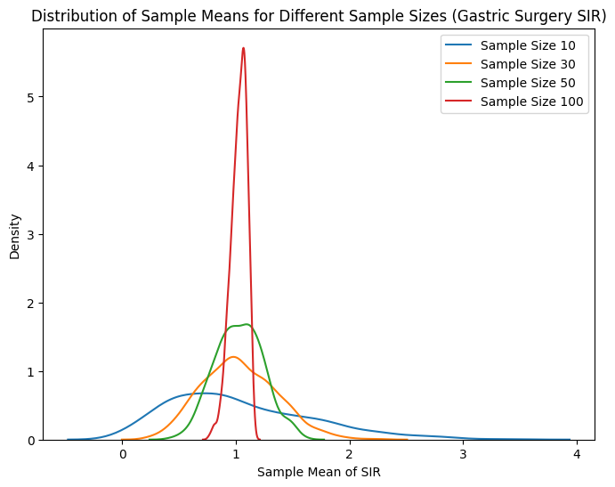

```python
plt.figure(figsize=(8, 6))

for n, means in sample_means.items():
    sns.kdeplot(means, label=f'Sample Size {n}')

plt.title('Distribution of Sample Means for Different Sample Sizes (Gastric Surgery SIR)')
plt.xlabel('Sample Mean of SIR')
plt.ylabel('Density')
plt.legend()

plt.show()
```

The density plots show that with larger sample sizes, the spread of the sample means decreases, indicating less variability and a closer approximation to the normal distribution.

The observed trend of decreasing standard deviation with increasing sample size supports the Central Limit Theorem. This demonstrates that for the SIR values of gastric surgeries, as the sample size increases, the distribution of sample means approximates a normal distribution, validating the CLT.

# Hypothesis Testing on the dataset

## Hypothesis 1:

- Null Hypothesis: Hospitals with a bed capacity above 250 have a lower average SIR in comparison to smaller hospitals.
- Alternative Hypothesis: Hospitals with a bed capacity above 250 have a higher average Standardized Infection Ratio (SIR) in comparison to smaller hospitals.

```python
from scipy import stats

community_large_hospitals = df[(df['facility_type'] == 'Community, >250 Beds')]
community_small_hospitals = df[(df['facility_type'] == 'Community, <125 Beds') |
                                   (df['facility_type'] == 'Community, 125-250 Beds')]

mean_sir_community_large = community_large_hospitals['sir'].mean()
mean_sir_community_small = community_small_hospitals['sir'].mean()


t_stat_community, p_value_ttest_community = stats.ttest_ind(
    community_large_hospitals['sir'].dropna(),
    community_small_hospitals['sir'].dropna(),
    equal_var=False
)

{
    "mean_sir_community_large_hospitals": mean_sir_community_large,
    "mean_sir_community_small_hospitals": mean_sir_community_small,
    "t-test_community": {"t_statistic": t_stat_community, "p_value": p_value_ttest_community}
}
```

```
{'mean_sir_community_large_hospitals': 0.7422107538626666,
 'mean_sir_community_small_hospitals': 0.8666134358011697,
 't-test_community': {'t_statistic': -1.3005296317423432,
  'p_value': 0.19381675503806198}}
```

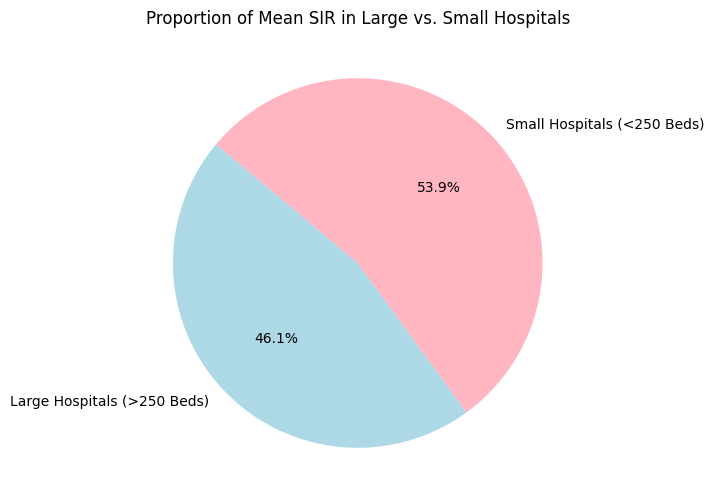

```python
labels = ['Large Hospitals (>250 Beds)', 'Small Hospitals (<250 Beds)']
all_large_hospitals_sir = df[df['facility_type'].str.contains(">250", na=False)]['sir']
all_small_hospitals_sir = df[df['facility_type'].str.contains("<125", na=False) |
                                 df['facility_type'].str.contains("125-250", na=False)]['sir']

mean_sir_large_hospitals = all_large_hospitals_sir.mean()
mean_sir_small_hospitals = all_small_hospitals_sir.mean()

means = [mean_sir_large_hospitals, mean_sir_small_hospitals]

plt.figure(figsize=(6, 6))
plt.pie(means, labels=labels, autopct='%1.1f%%', startangle=140, colors=['lightblue', 'lightpink'])
plt.title('Proportion of Mean SIR in Large vs. Small Hospitals')
```

### Conclusion:

The t-test yields a P-value of 0.194, which is more than the traditional alpha requirement of 0.05.

Given these findings, the difference in the average Standardized Infection Ratio (SIR) between large and small hospitals is unlikely to be statistically significant.

As a result, it is not plausible to claim that larger hospitals have a lower average SIR when compared to smaller hospitals.

In practice, the findings of this study imply that the number of beds in a hospital has no significant effect on the Standardized Infection Ratio, as demonstrated in the studied data.

## Hypothesis 2: Comparative Analysis of Standardized Infection Ratios in Cesarean Sections and Colon Surgeries.

- Null Hypothesis: There is no difference in the Standardized Infection Ratios between Cesarean sections and Colon surgeries.
- Alternative Hypothesis: There is a difference in the Standardized Infection Ratios between Cesarean sections and Colon surgeries.

```python
cesarean_sir = df[df['operative_procedure'] == 'cesarean section']['sir']
colon_surgery_sir = df[df['operative_procedure'] == 'colon surgery']['sir']

t_stat_procedure, p_value_procedure = stats.ttest_ind(cesarean_sir.dropna(), colon_surgery_sir.dropna(), equal_var=False)

t_stat_procedure, p_value_procedure
```

```
(0.5199342081943438, 0.6038181101650832)
```

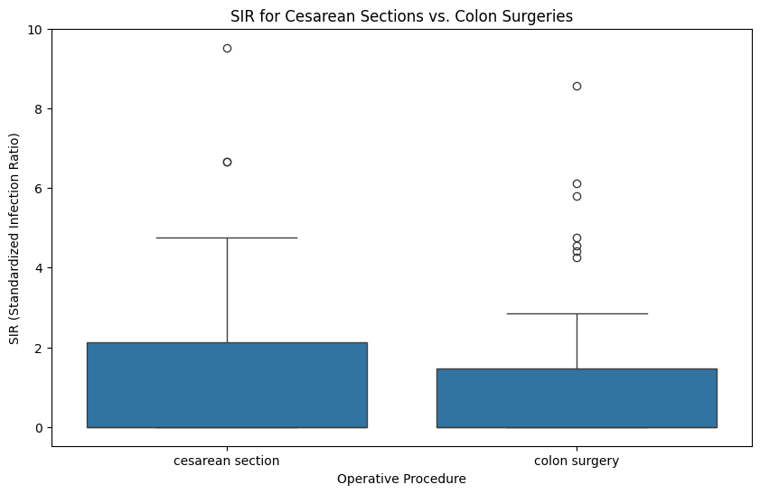

```python
plt.figure(figsize=(10, 6))

sns.boxplot(data=df, x='operative_procedure', y='sir', order=['cesarean section', 'colon surgery'])

plt.title('SIR for Cesarean Sections vs. Colon Surgeries')
plt.xlabel('Operative Procedure')
plt.ylabel('SIR (Standardized Infection Ratio)')

plt.show()
```

Statistical Test:

There is no statistically significant evidence to indicate the presence of a discrepancy in the average SIRs between Cesarean sections and colon operations, as the p-value (0.604) is substantially larger than the conventional alpha criterion of 0.05. To put it plainly, the data does not lend credence to the idea that the SIRs for these two procedures are significantly different.

## Hypothesis 3: Evaluation of Hospital Attainment of the 2020 Standardized Infection Ratio (SIR) Objective

- Null Hypothesis (H0): Half of the hospitals achieved the 2020 target for reducing the Standardized Infection Ratio..
- Alternative Hypothesis (H1): More than Half of the hospitals achieved the 2020 target for reducing the Standardized Infection Ratio.

```python
!pip install statsmodels
```

[output not shown]

```python
from statsmodels.stats.proportion import proportions_ztest

met_2020_goal = df['met_2020_goal'] == 1
n_hospitals = len(df)
n_met_goal = met_2020_goal.sum()

hypothetical_proportion = 0.5
stat, p_value = proportions_ztest(n_met_goal, n_hospitals, hypothetical_proportion)

observed_proportion = n_met_goal / n_hospitals

observed_proportion, stat, p_value
```

```
(0.6843800322061192, 17.123376799370078, 9.934184222439486e-66)
```

The research resulted in a very significant p-value of roughly $9.93 \times 10^{-66}$ , which is far less than the conventional alpha threshold of 0.05.

The exceptionally small p-value provides strong evidence to reject the null hypothesis that only 50% of hospitals achieved the 2020 SIR objective.

The discovery that `68.44%` of hospitals have achieved the 2020 SIR objective is evidence of the significant endeavors and progress made in infection control inside these establishments.

This suggests that a considerably larger percentage of hospitals have successfully reached the objective in comparison to the hypothetical benchmark of 50%.

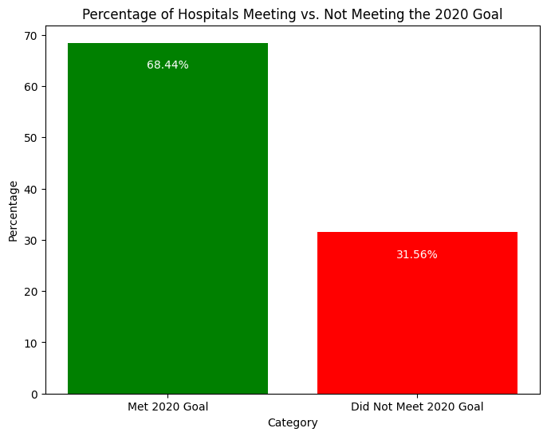

```python
percentage_met_goal = (n_met_goal / n_hospitals) * 100
percentage_not_met_goal = ((n_hospitals - n_met_goal) / n_hospitals) * 100
percentages = [percentage_met_goal, percentage_not_met_goal]
categories = ['Met 2020 Goal', 'Did Not Meet 2020 Goal']

plt.figure(figsize=(8, 6))
plt.bar(categories, percentages, color=['green', 'red'])
plt.title('Percentage of Hospitals Meeting vs. Not Meeting the 2020 Goal')
plt.xlabel('Category')
plt.ylabel('Percentage')
plt.xticks(categories)
plt.yticks(range(0, int(max(percentages)) + 10, 10))

for i in range(len(percentages)):
    plt.text(i, percentages[i] - 5, f'{percentages[i]:.2f}%', ha = 'center', color='white')

plt.show()
```

## Hypothesis 4: Examination of the Difference in Surgical Site Infections Between Predicted and Reported

- Null Hypothesis: The mean reported infections are lower than the mean projected infections.
- Alternative Hypothesis: The mean reported infections are not lower than the mean projected infections.

```python
reported_infections = df['infections_reported']
predicted_infections = df['infections_predicted']

t_stat_reported_vs_predicted, p_value_reported_vs_predicted = stats.ttest_rel(reported_infections, predicted_infections)

t_stat_reported_vs_predicted, p_value_reported_vs_predicted
```

```
(-3.4091322213817343, 0.0006655919468507733)
```

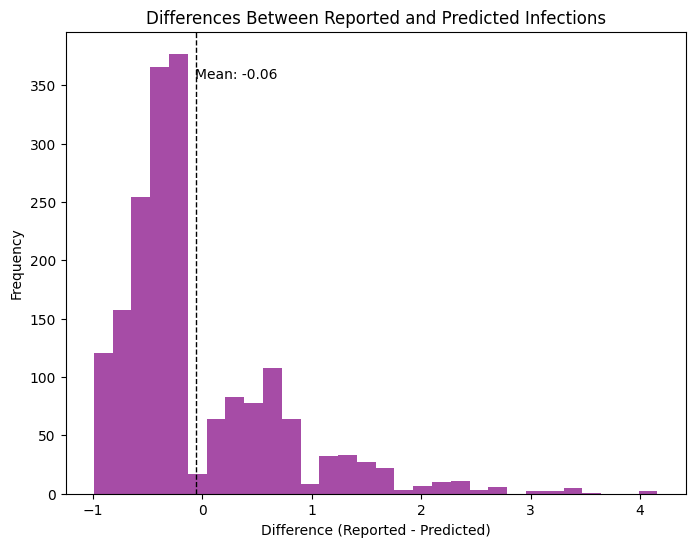

```python
differences = reported_infections - predicted_infections

plt.figure(figsize=(8, 6))
plt.hist(differences, bins=30, color='purple', alpha=0.7)
plt.axvline(differences.mean(), color='k', linestyle='dashed', linewidth=1)
plt.title('Differences Between Reported and Predicted Infections')
plt.xlabel('Difference (Reported - Predicted)')
plt.ylabel('Frequency')
plt.text(differences.mean() * 1.1, plt.ylim()[1] * 0.9, f'Mean: {differences.mean():.2f}', color='black')

plt.show()
```

The negative t-statistic indicates that the mean reported infections are lower than the mean projected infections.

The p-value, which is below the normal alpha threshold of 0.05, demonstrates a statistically significant disparity between the reported and expected infection rates.

The outcome confirms the hypothesis, demonstrating a significant difference between the reported and projected SSIs.

The discrepancy may arise due to several variables, such as the omission of developments in infection control techniques in the predictive models or the possibility of underreporting of illnesses.